# Fundamentos del Proyecto de Ciencia de Datos - Análisis de Diabetes

## Contexto

La diabetes es una de las enfermedades más frecuentes a nivel mundial y el número de pacientes diabéticos va en aumento con el paso de los años. La causa principal de la diabetes sigue siendo desconocida, pero los científicos creen que tanto los factores genéticos como el estilo de vida ambiental juegan un papel importante en la diabetes.

Hace unos años se realizó una investigación sobre una tribu en América que se llama la tribu Pima (también conocida como los indios Pima). En esta tribu, se encontró que las damas son propensas a la diabetes desde muy temprano. Se impusieron varias restricciones a la selección de estas instancias de una base de datos más grande. En particular, todos los pacientes eran mujeres de al menos 21 años de edad de ascendencia indígena pima.

## Objetivo

Aquí, estamos analizando diferentes aspectos de la diabetes en la tribu de los indios pima mediante el análisis exploratorio de datos.

## Diccionario de datos

El conjunto de datos tiene la siguiente información:

*Pregnancies: Número de veces embarazadas

*Glucose: concentración de Glucose en plasma a las 2 horas en una prueba de tolerancia oral a la Glucose

*Blood pressure: presión arterial diastólica (mm Hg)

*SkinThickness: Grosor del pliegue cutáneo del tríceps (mm)

*Insulin: prueba de insulina sérica de 2 horas (mu U/ml)

*BMI: índice de masa corporal (peso en kg /( altura en m)^2)

*DiabetesPedigreeFunction : una función que califica la probabilidad de diabetes en función de los antecedentes familiares

*Age: Edad en años

*Outcome: Variable de clase (0: la persona no es diabética o 1: la persona es diabética)

## P 1: Importe las bibliotecas necesarias y explique brevemente el uso de cada biblioteca (3 Puntos)

```python
# remove _____ & write the appropriate library name
import numpy as np
import pandas as pd

import seaborn as sns
import matplotlib as plt
import matplotlib.pyplot as plp  # Asegúrate de importar pyplot de matplotlib
%matplotlib inline
```

#### Escriba su respuesta aquí:

Ans 1: Numpy es para trabajar con datos multidimensionales, pandas para trabajar con datos estructurados (tabulares, multidimensionales y potencialmente heterogéneos), *matplotlib* para trabajar con gráficos y personalizar estos gráficos con etiquetas, leyendas, títulos, colores y estilos, seaborn es complementario a Matplotlib y analiza la visualización de datos estadísticos

## P 2: Lea el conjunto de datos dado (1 Punto)

```python
# remove _____ & write the appropriate function name

pima = pd.read_csv("diabetes.csv")
```

## P3. Muestra los últimos 10 registros del conjunto de datos. ¿Cuántas columnas hay? (1 punto)

```python
# remove ______ and write the appropriate number in the function
pima.tail(10)
```

|  | Pregnancies | Glucose | BloodPressure | SkinThickness | Insulin | BMI | DiabetesPedigreeFunction | Age | Outcome |
| --- | --- | --- | --- | --- | --- | --- | --- | --- | --- |
| 758 | 1 | 106 | 76 | 20 | 79 | 37.5 | 0.197 | 26 | 0 |
| 759 | 6 | 190 | 92 | 20 | 79 | 35.5 | 0.278 | 66 | 1 |
| 760 | 2 | 88 | 58 | 26 | 16 | 28.4 | 0.766 | 22 | 0 |
| 761 | 9 | 170 | 74 | 31 | 79 | 44.0 | 0.403 | 43 | 1 |
| 762 | 9 | 89 | 62 | 20 | 79 | 22.5 | 0.142 | 33 | 0 |
| 763 | 10 | 101 | 76 | 48 | 180 | 32.9 | 0.171 | 63 | 0 |
| 764 | 2 | 122 | 70 | 27 | 79 | 36.8 | 0.340 | 27 | 0 |
| 765 | 5 | 121 | 72 | 23 | 112 | 26.2 | 0.245 | 30 | 0 |
| 766 | 1 | 126 | 60 | 20 | 79 | 30.1 | 0.349 | 47 | 1 |
| 767 | 1 | 93 | 70 | 31 | 79 | 30.4 | 0.315 | 23 | 0 |

#### Escriba su respuesta aquí:

Ans 3: Hay 9 columnas

## P4. Mostrar los primeros 10 registros del conjunto de datos (1 Punto)

```python
# remove _____ & write the appropriate function name and the number of rows to get in the output

pima.head(10)
```

|  | Pregnancies | Glucose | BloodPressure | SkinThickness | Insulin | BMI | DiabetesPedigreeFunction | Age | Outcome |
| --- | --- | --- | --- | --- | --- | --- | --- | --- | --- |
| 0 | 6 | 148 | 72 | 35 | 79 | 33.600000 | 0.627 | 50 | 1 |
| 1 | 1 | 85 | 66 | 29 | 79 | 26.600000 | 0.351 | 31 | 0 |
| 2 | 8 | 183 | 64 | 20 | 79 | 23.300000 | 0.672 | 32 | 1 |
| 3 | 1 | 89 | 66 | 23 | 94 | 28.100000 | 0.167 | 21 | 0 |
| 4 | 0 | 137 | 40 | 35 | 168 | 43.100000 | 2.288 | 33 | 1 |
| 5 | 5 | 116 | 74 | 20 | 79 | 25.600000 | 0.201 | 30 | 0 |
| 6 | 3 | 78 | 50 | 32 | 88 | 31.000000 | 0.248 | 26 | 1 |
| 7 | 10 | 115 | 69 | 20 | 79 | 35.300000 | 0.134 | 29 | 0 |
| 8 | 2 | 197 | 70 | 45 | 543 | 30.500000 | 0.158 | 53 | 1 |
| 9 | 8 | 125 | 96 | 20 | 79 | 31.992578 | 0.232 | 54 | 1 |

## P5. ¿Qué entiendes por la dimensión del conjunto de datos? Encuentre la dimensión del marco de datos `pima`. (1 punto)

```python
# remove _____ & write the appropriate function name

pima.shape
```

```
(768, 9)
```

#### Escriba su respuesta aquí:

Ans 5: El número de filas y columnas del conjunto de datos

## P6. ¿Qué entiendes por el tamaño del conjunto de datos? Encuentre el tamaño del marco de datos `pima`. (1 punto)

```python
# remove _____ & write the appropriate function name

pima.shape
```

```
(768, 9)
```

#### Escriba su respuesta aquí:

Ans 6: Es la muestra presente, son 768 registros

## P7. ¿Cuáles son los tipos de datos de todas las variables en el conjunto de datos? (2 puntos)

**Sugerencia: utilice la función info() para obtener toda la información sobre el conjunto de datos.**

```python
# remove _____ & write the appropriate function name

#pima.dtypes.value_counts()
pima.info()
```

```
<class 'pandas.core.frame.DataFrame'>
RangeIndex: 768 entries, 0 to 767
Data columns (total 9 columns):
 #   Column                    Non-Null Count  Dtype
---  ------                    --------------  -----
 0   Pregnancies               768 non-null    int64
 1   Glucose                   768 non-null    int64
 2   BloodPressure             768 non-null    int64
 3   SkinThickness             768 non-null    int64
 4   Insulin                   768 non-null    int64
 5   BMI                       768 non-null    float64
 6   DiabetesPedigreeFunction  768 non-null    float64
 7   Age                       768 non-null    int64
 8   Outcome                   768 non-null    int64
dtypes: float64(2), int64(7)
memory usage: 54.1 KB
```

#### Escriba su respuesta aquí:

Ans 7: int64 que son variables numéricas enteras y float64 que son variables numéricas que admiten decimales

## P8. ¿Qué entendemos por valores perdidos? ¿Hay valores faltantes en el marco de datos `pima`? (2 puntos)

```python
# remove _____ & write the appropriate function name

pima.isnull().values.any()
```

```
False
```

#### Escriba su respuesta aquí:

Ans 8: Son valores null lo que quiere decir que son datos que no estan presentes dentro del conjunto de datos evaluados, como el resultado es False entonces no hay valores faltantes en el csv pima.

## P9. ¿Qué representan las estadísticas de resumen de los datos? Encuentre las estadísticas de resumen para todas las variables excepto 'Outcome' en los datos de 'pima'. Tome una columna/variable de la tabla de salida y explique todas sus medidas estadísticas. (3 puntos)

```python
# remove _____ & write the appropriate function name

pima.iloc[:,0:8].describe()
```

|  | Pregnancies | Glucose | BloodPressure | SkinThickness | Insulin | BMI | DiabetesPedigreeFunction | Age |
| --- | --- | --- | --- | --- | --- | --- | --- | --- |
| count | 768.000000 | 768.000000 | 768.000000 | 768.000000 | 768.000000 | 768.000000 | 768.000000 | 768.000000 |
| mean | 3.845052 | 121.675781 | 72.250000 | 26.447917 | 118.270833 | 32.450805 | 0.471876 | 33.240885 |
| std | 3.369578 | 30.436252 | 12.117203 | 9.733872 | 93.243829 | 6.875374 | 0.331329 | 11.760232 |
| min | 0.000000 | 44.000000 | 24.000000 | 7.000000 | 14.000000 | 18.200000 | 0.078000 | 21.000000 |
| 25% | 1.000000 | 99.750000 | 64.000000 | 20.000000 | 79.000000 | 27.500000 | 0.243750 | 24.000000 |
| 50% | 3.000000 | 117.000000 | 72.000000 | 23.000000 | 79.000000 | 32.000000 | 0.372500 | 29.000000 |
| 75% | 6.000000 | 140.250000 | 80.000000 | 32.000000 | 127.250000 | 36.600000 | 0.626250 | 41.000000 |
| max | 17.000000 | 199.000000 | 122.000000 | 99.000000 | 846.000000 | 67.100000 | 2.420000 | 81.000000 |

#### Escriba su respuesta aquí:

Ans 9: Representan las medidas de tendencia central y dispersión de los datos, tambien los percentiles, los valores mínimo y máximos. Tomando como referencia la edad, se tiene: Muestra: 768; Promedio: La edad promedio es de 33,24 años; Desviación estándar: En promedio la edad se desvía 11,76 años del promedio; Mínimo: La persona más joven de la base de datos tiene 21 años; 25%: El 25% de los datos tienen hasta 24 años; 50%: La mediana de los datos es de 29 años; 75%: El 75% de los datos tienen hasta 41 años; Máximo: La persona más vieja de la base de datos tiene 81 años;

## P 10. Grafique la distribución para la variable 'BloodPressure'. Escribe observaciones detalladas de la gráfica. (2 puntos)

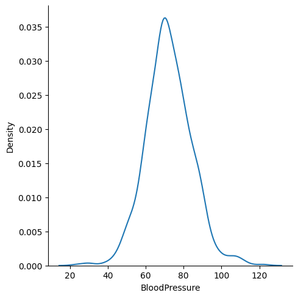

```python
# remove _____ & write the appropriate library name

sns.displot(pima['BloodPressure'], kind='kde')
plp.show()
```

#### Escriba su respuesta aquí:

Ans 10: La presión arterial esta mayormente concentrada entre los 60 (mm) y 80 (mm) para una gran cantidad de registros.

## P 11. ¿Cuál es el 'BMI' de la persona que tiene la 'Glucose' más alta? (1 punto)

```python
# remove _____ & write the appropriate function name

pima[pima['Glucose']==pima['Glucose'].max()]['BMI']
```

```
661    42.9
Name: BMI, dtype: float64
```

#### Escriba su respuesta aquí:

Ans 11: EL BMI de la persona con la glucosa más alta es 42,9

## P12.

### 12.1 ¿Cuál es la media de la variable 'BMI'?

### 12.2 ¿Cuál es la mediana de la variable 'BMI'?

### 12.3 ¿Cuál es la moda de la variable 'BMI'?

### 12.4 ¿Son iguales las tres medidas de tendencia central?

### (3 puntos)

```python
# remove _____ & write the appropriate function name

m1 = pima['BMI'].mean()  # mean
print(m1)
m2 = pima['BMI'].median()  # median
print(m2)
m3 = pima['BMI'].mode()[0]  # mode
print(m3)
```

```
32.45080515543619
32.0
32.0
```

#### Escriba su respuesta aquí:

Ans 12: La media es 32,45, la mediana y moda son 32. Como la media es mayor a la mediana y la moda se espera que la distribución de la variable "BMI" sea asimétrica a la derecha ---

## P13. ¿Cuántas mujeres tienen niveles de 'Glucosa' por encima del nivel medio de 'Glucosa'? (1 punto)

```python
# remove _____ & write the appropriate function name

pima[pima['Glucose']>pima['Glucose'].mean()].shape[0]

#shape[0] es sin dimensiones
```

```
343
```

#### Escriba su respuesta aquí:

Ans 13: 343 mujeres

## P14. ¿Cuántas mujeres tienen su 'BloodPressure' igual a la mediana de BloodPressure' y su 'BMI' menor que la mediana de 'BMI'? (2 puntos)

```python
# remove _____ & write the appropriate column name

pima[(pima['BloodPressure']==pima['BloodPressure'].median()) & (pima['BMI']<pima['BMI'].median())]
```

|  | Pregnancies | Glucose | BloodPressure | SkinThickness | Insulin | BMI | DiabetesPedigreeFunction | Age | Outcome |
| --- | --- | --- | --- | --- | --- | --- | --- | --- | --- |
| 14 | 5 | 166 | 72 | 19 | 175 | 25.8 | 0.587 | 51 | 1 |
| 93 | 4 | 134 | 72 | 20 | 79 | 23.8 | 0.277 | 60 | 1 |
| 103 | 1 | 81 | 72 | 18 | 40 | 26.6 | 0.283 | 24 | 0 |
| 205 | 5 | 111 | 72 | 28 | 79 | 23.9 | 0.407 | 27 | 0 |
| 299 | 8 | 112 | 72 | 20 | 79 | 23.6 | 0.840 | 58 | 0 |
| 325 | 1 | 157 | 72 | 21 | 168 | 25.6 | 0.123 | 24 | 0 |
| 330 | 8 | 118 | 72 | 19 | 79 | 23.1 | 1.476 | 46 | 0 |
| 366 | 6 | 124 | 72 | 20 | 79 | 27.6 | 0.368 | 29 | 1 |
| 380 | 1 | 107 | 72 | 30 | 82 | 30.8 | 0.821 | 24 | 0 |
| 393 | 4 | 116 | 72 | 12 | 87 | 22.1 | 0.463 | 37 | 0 |
| 406 | 4 | 115 | 72 | 20 | 79 | 28.9 | 0.376 | 46 | 1 |
| 446 | 1 | 100 | 72 | 12 | 70 | 25.3 | 0.658 | 28 | 0 |
| 460 | 9 | 120 | 72 | 22 | 56 | 20.8 | 0.733 | 48 | 0 |
| 488 | 4 | 99 | 72 | 17 | 79 | 25.6 | 0.294 | 28 | 0 |
| 497 | 2 | 81 | 72 | 15 | 76 | 30.1 | 0.547 | 25 | 0 |
| 510 | 12 | 84 | 72 | 31 | 79 | 29.7 | 0.297 | 46 | 1 |
| 568 | 4 | 154 | 72 | 29 | 126 | 31.3 | 0.338 | 37 | 0 |
| 615 | 3 | 106 | 72 | 20 | 79 | 25.8 | 0.207 | 27 | 0 |
| 635 | 13 | 104 | 72 | 20 | 79 | 31.2 | 0.465 | 38 | 1 |
| 644 | 3 | 103 | 72 | 30 | 152 | 27.6 | 0.730 | 27 | 0 |
| 717 | 10 | 94 | 72 | 18 | 79 | 23.1 | 0.595 | 56 | 0 |
| 765 | 5 | 121 | 72 | 23 | 112 | 26.2 | 0.245 | 30 | 0 |

```python
# remove _____ & write the appropriate column name
pima[(pima['BloodPressure']==pima['BloodPressure'].median()) & (pima['BMI']<pima['BMI'].median())].shape[0]
```

```
22
```

#### Escriba su respuesta aquí:

Ans 14: 22 mujeres

## P15. Cree un diagrama de pares para las variables 'Glucose', 'SkinThickness' y 'DiabetesPedigreeFunction'. Escribe tus observaciones de la gráfica. (4 puntos)

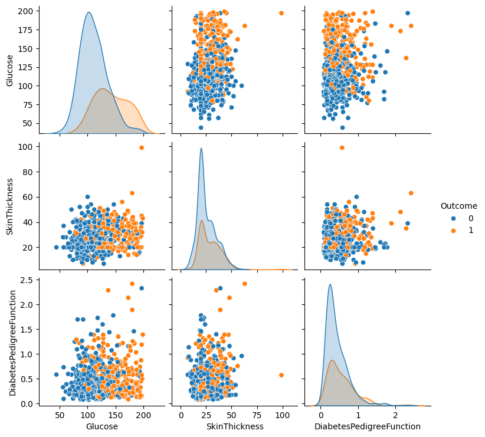

```python
# remove _____ & write the appropriate function name

sns.pairplot(data=pima,vars=['Glucose', 'SkinThickness', 'DiabetesPedigreeFunction'], hue='Outcome')
plp.show()
```

## P16. Dibuje el diagrama de dispersión entre 'Glucose' e 'Insulin'. Escribe tus observaciones de la gráfica. (2 puntos)

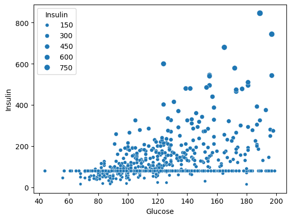

```python
# remove _____ & write the appropriate function name
sns.scatterplot(x='Glucose',y='Insulin',data=pima,size = "Insulin")
plp.show()
```

## P 17. Dibuje el diagrama de caja para la variable 'Age'. ¿Hay valores atípicos? (2 puntos)

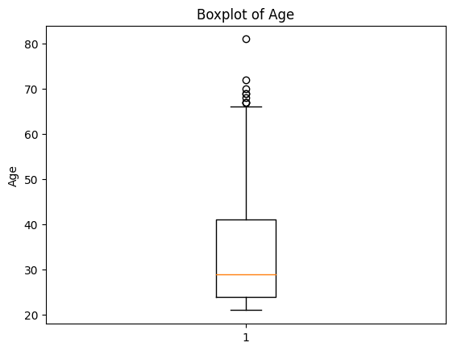

```python
# remove _____ & write the appropriate function and column name

plp.boxplot(pima['Age'])

plp.title('Boxplot of Age')
plp.ylabel('Age')
plp.show()
```

#### Escriba su respuesta aquí:

Ans 17: Si existen valores atípicos por sobre la línea horizontal

## P18. Dibuje histogramas para la variable 'Age' para comprender el número de mujeres en diferentes grupos de edad dado si tienen diabetes o no. Explique ambos histogramas y compárelos. (3 puntos)

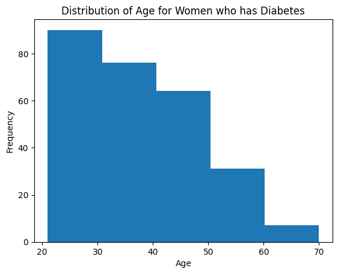

```python
# remove _____ & write the appropriate function and column name

plp.hist(pima[pima['Outcome']==1]['Age'], bins = 5)
plp.title('Distribution of Age for Women who has Diabetes')
plp.xlabel('Age')
plp.ylabel('Frequency')
plp.show()
```

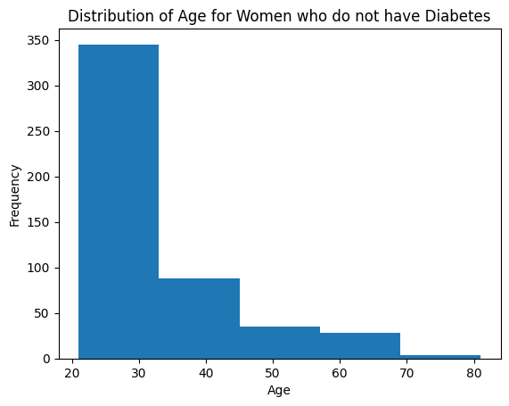

```python
# remove _____ & write the appropriate function and column name

plp.hist(pima[pima['Outcome']==0]['Age'], bins = 5)
plp.title('Distribution of Age for Women who do not have Diabetes')
plp.xlabel('Age')
plp.ylabel('Frequency')
plp.show()
```

## P 19. ¿Cuál es el Rango Intercuartílico de todas las variables? ¿Por qué se usa esto? ¿Qué trama visualiza lo mismo? (2 puntos)

```python
# remove _____ & write the appropriate variable name

Q1 = pima.quantile(0.25)
Q3 = pima.quantile(0.75)
IQR = Q3 - Q1
print(IQR)
```

```
Pregnancies                  5.0000
Glucose                     40.5000
BloodPressure               16.0000
SkinThickness               12.0000
Insulin                     48.2500
BMI                          9.1000
DiabetesPedigreeFunction     0.3825
Age                         17.0000
Outcome                      1.0000
dtype: float64
```

#### Escriba su respuesta aquí:

Ans 19: El rango intercuartilico representa el 50% central de los valores cuando se ordenan de menor a mayor, sirve para identificar la dispersión de los datos y para detectar valores atípicos. la trama que visualiza lo mismo es el gráfico boxplot

## Q 20. Encuentre y visualice la matriz de correlación. Escribe tus observaciones de la gráfica. (3 puntos)

```python
# remove _____ & write the appropriate function name and run the code

corr_matrix = pima.iloc[:,0:8].corr()
corr_matrix
```

|  | Pregnancies | Glucose | BloodPressure | SkinThickness | Insulin | BMI | DiabetesPedigreeFunction | Age |
| --- | --- | --- | --- | --- | --- | --- | --- | --- |
| Pregnancies | 1.000000 | 0.128022 | 0.208987 | 0.009393 | -0.018780 | 0.021546 | -0.033523 | 0.544341 |
| Glucose | 0.128022 | 1.000000 | 0.219765 | 0.158060 | 0.396137 | 0.231464 | 0.137158 | 0.266673 |
| BloodPressure | 0.208987 | 0.219765 | 1.000000 | 0.130403 | 0.010492 | 0.281222 | 0.000471 | 0.326791 |
| SkinThickness | 0.009393 | 0.158060 | 0.130403 | 1.000000 | 0.245410 | 0.532552 | 0.157196 | 0.020582 |
| Insulin | -0.018780 | 0.396137 | 0.010492 | 0.245410 | 1.000000 | 0.189919 | 0.158243 | 0.037676 |
| BMI | 0.021546 | 0.231464 | 0.281222 | 0.532552 | 0.189919 | 1.000000 | 0.153508 | 0.025748 |
| DiabetesPedigreeFunction | -0.033523 | 0.137158 | 0.000471 | 0.157196 | 0.158243 | 0.153508 | 1.000000 | 0.033561 |
| Age | 0.544341 | 0.266673 | 0.326791 | 0.020582 | 0.037676 | 0.025748 | 0.033561 | 1.000000 |

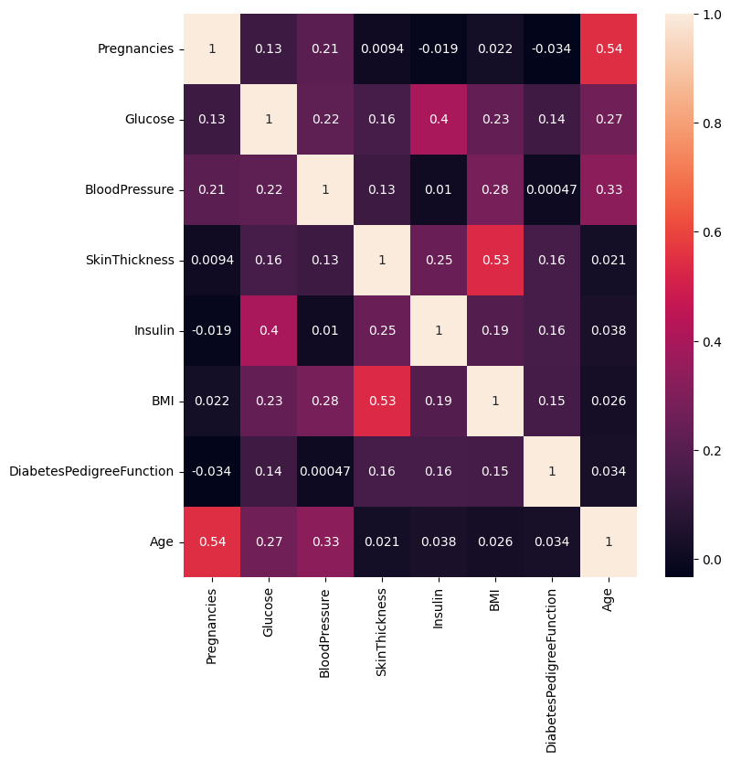

```python
# remove _____ & write the appropriate function name

plp.figure(figsize=(8,8))
sns.heatmap(corr_matrix, annot = True)

# display the plot
plp.show()
```

#### Escriba su respuesta aquí:

Ans 20: Se aprecia que las mayores relaciones positivas (correlación mayor a 0.5) estan en: a mayor edad mayor número de embarazos, a mayor índice de masa corporal (BMI) mayor es el grosor del pliegue cutáneo del tríceps (SkinThickness). También hay relaciones casi nulas como la edad con la insulina (0.038) con el índice de masa corporal (0.026)

```python
!jupyter nbconvert --to html ELA_Proyecto_1_Diabetes.ipynb
```

```
[NbConvertApp] Converting notebook ELA_Proyecto_1_Diabetes.ipynb to html
[NbConvertApp] Writing 1258957 bytes to ELA_Proyecto_1_Diabetes.html
```